# PPOL670 | Introduction to Data Science

Strings and Text-as-Data Walkthrough

# String Manipulations

## Example 1

We’ll use what we know of manipulation to clean the following string.

```r
dirty_string = "22Clean 5674.5this $%&*_@string!"
dirty_string
```

```
## [1] "22Clean 5674.5this $%&*_@string!"
```

Remove the numbers…

```r
dirty_string = str_remove_all(dirty_string,"\\d")
dirty_string
```

```
## [1] "Clean .this $%&*_@string!"
```

Remove the odd punctuation.

```r
dirty_string = str_remove_all(dirty_string,"[:punct:]")
dirty_string
```

```
## [1] "Clean this $string"
```

```r
dirty_string = str_remove_all(dirty_string,"\\$")
dirty_string
```

```
## [1] "Clean this string"
```

### Example 2

```r
dirty_text <-"

    A comedian with no political experience has won the most votes in the first round of Ukraine's presidential elections, according to exit polls.

They say Volodymyr Zelenskiy - who played the president on TV - received 30.4% of the vote, with current leader Petro Poroshenko second on 17.8%.

The two - who have expressed largely pro-EU opinions - are set to take part in a run-off election next month.


"

dirty_text
```

```
## [1] "\n\n    A comedian with no political experience has won the most votes in the first round of Ukraine's presidential elections, according to exit polls.\n\nThey say Volodymyr Zelenskiy - who played the president on TV - received 30.4% of the vote, with current leader Petro Poroshenko second o…
```

Remove the excess white space

```r
dirty_text <- str_trim(dirty_text)
dirty_text
```

```
## [1] "A comedian with no political experience has won the most votes in the first round of Ukraine's presidential elections, according to exit polls.\n\nThey say Volodymyr Zelenskiy - who played the president on TV - received 30.4% of the vote, with current leader Petro Poroshenko second on 17.8%.…
```

Remove the spacing in the middle of the text (`\n` = “return”/“new line”)

```r
dirty_text <- str_remove_all(dirty_text,"\\n")
dirty_text
```

```
## [1] "A comedian with no political experience has won the most votes in the first round of Ukraine's presidential elections, according to exit polls.They say Volodymyr Zelenskiy - who played the president on TV - received 30.4% of the vote, with current leader Petro Poroshenko second on 17.8%.The …
```

Let’s remove the subordinate clauses.

```r
text_list <- str_split(dirty_text," - ")
text_list
```

```
## [[1]]
## [1] "A comedian with no political experience has won the most votes in the first round of Ukraine's presidential elections, according to exit polls.They say Volodymyr Zelenskiy"
## [2] "who played the president on TV"
## [3] "received 30.4% of the vote, with current leader Petro Poroshenko second on 17.8%.The two"
## [4] "who have expressed largely pro-EU opinions"
## [5] "are set to take part in a run-off election next month."
```

```r
text_list <- text_list[[1]]
text_list <- text_list[c(-2,-4)]
text_list
```

```
## [1] "A comedian with no political experience has won the most votes in the first round of Ukraine's presidential elections, according to exit polls.They say Volodymyr Zelenskiy"
## [2] "received 30.4% of the vote, with current leader Petro Poroshenko second on 17.8%.The two"
## [3] "are set to take part in a run-off election next month."
```

```r
dirty_text <-  str_c(text_list,collapse = " ")
dirty_text
```

```
## [1] "A comedian with no political experience has won the most votes in the first round of Ukraine's presidential elections, according to exit polls.They say Volodymyr Zelenskiy received 30.4% of the vote, with current leader Petro Poroshenko second on 17.8%.The two are set to take part in a run-o…
```

Add spaces between the sentences (but need to make sure we don’t split up the percentages!)

```r
dirty_text <- str_replace_all(dirty_text,"\\.(?!\\d)",". ")
dirty_text
```

```
## [1] "A comedian with no political experience has won the most votes in the first round of Ukraine's presidential elections, according to exit polls. They say Volodymyr Zelenskiy received 30.4% of the vote, with current leader Petro Poroshenko second on 17.8%. The two are set to take part in a run…
```

# Text as Data: Exploring Inaugural Presidential Speeches

Read data in and clean.

```r
inaug_dat <-
  read_csv("inaug_speeches.csv")
head(inaug_dat)
```

```
## # A tibble: 6 x 5
##      X1 Name       `Inaugural Address` Date        text
##   <dbl> <chr>      <chr>               <chr>       <chr>
## 1     4 George Wa… First Inaugural Ad… Thursday, … "Fellow-Citizens of the Sena…
## 2     5 George Wa… Second Inaugural A… Monday, Ma… "Fellow Citizens:  \xa0\xa0I…
## 3     6 John Adams Inaugural Address   Saturday, … "\xa0\xa0WHEN it was first p…
## 4     7 Thomas Je… First Inaugural Ad… Wednesday,… "Friends and Fellow-Citizens…
## 5     8 Thomas Je… Second Inaugural A… Monday, Ma… "\xa0\xa0PROCEEDING, fellow-…
## 6     9 James Mad… First Inaugural Ad… Saturday, … "\xa0\xa0UNWILLING to depart…
```

Clean data.

```r
dat <-
  inaug_dat %>%
  transmute(president = str_to_lower(Name) %>% str_replace_all(.," ","_"),
            address = ifelse(str_detect(`Inaugural Address`,"First"),"first","second"),
            date = as.Date(Date,"%A, %B %d, %Y"),
            year = lubridate::year(date),
            length = str_count(text),
            text = text)

# Adjust for one problematic date
dat[dat$president=="bill_clinton" & dat$address=="second",]$date = as.Date("1997-01-20")
dat[dat$president=="bill_clinton" & dat$address=="second",]$year = 1997

head(dat)
```

```
## # A tibble: 6 x 6
##   president     address date        year length text
##   <chr>         <chr>   <date>     <dbl>  <int> <chr>
## 1 george_washi… first   1789-04-30  1789   8641 "Fellow-Citizens of the Senate …
## 2 george_washi… second  1793-03-04  1793    805 "Fellow Citizens:  \xa0\xa0I AM…
## 3 john_adams    second  1797-03-04  1797  13914 "\xa0\xa0WHEN it was first perc…
## 4 thomas_jeffe… first   1801-03-04  1801  10170 "Friends and Fellow-Citizens:  …
## 5 thomas_jeffe… second  1805-03-04  1805  12947 "\xa0\xa0PROCEEDING, fellow-cit…
## 6 james_madison first   1809-03-04  1809   7031 "\xa0\xa0UNWILLING to depart fr…
```

Let’s look at the length of speeches over time.

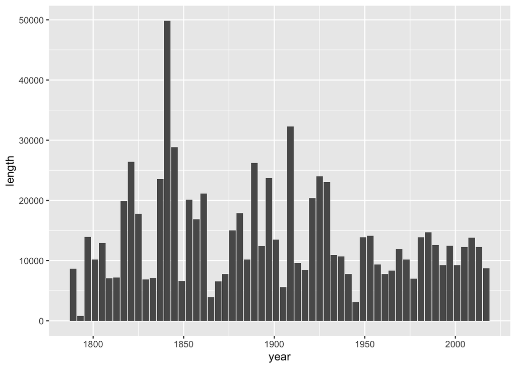

```r
dat %>%
  ggplot(aes(year,length)) +
  geom_col()
```

Who was the most/least verbose?

```r
dat %>%
  filter(max(length)==length) %>%
  select(president,length)
```

```
## # A tibble: 1 x 2
##   president              length
##   <chr>                   <int>
## 1 william_henry_harrison  49871
```

```r
dat %>%
  filter(min(length)==length) %>%
  select(president,length)
```

```
## # A tibble: 1 x 2
##   president         length
##   <chr>              <int>
## 1 george_washington    805
```

Convert text to tidy format.

```r
text_dat <-
  dat %>%
  unnest_tokens(word,text)

head(text_dat)
```

```
## # A tibble: 6 x 6
##   president         address date        year length word
##   <chr>             <chr>   <date>     <dbl>  <int> <chr>
## 1 george_washington first   1789-04-30  1789   8641 fellow
## 2 george_washington first   1789-04-30  1789   8641 citizens
## 3 george_washington first   1789-04-30  1789   8641 of
## 4 george_washington first   1789-04-30  1789   8641 the
## 5 george_washington first   1789-04-30  1789   8641 senate
## 6 george_washington first   1789-04-30  1789   8641 and
```

Remove stopwords and digits.

```r
text_dat <-
  text_dat %>%
  anti_join(stop_words,by="word") %>%
  filter(!str_detect(word,"\\d")) %>%

  # From the TM package (must install if you don't have)
  mutate(word = tm::removePunctuation(word))


head(text_dat)
```

```
## # A tibble: 6 x 6
##   president         address date        year length word
##   <chr>             <chr>   <date>     <dbl>  <int> <chr>
## 1 george_washington first   1789-04-30  1789   8641 fellow
## 2 george_washington first   1789-04-30  1789   8641 citizens
## 3 george_washington first   1789-04-30  1789   8641 senate
## 4 george_washington first   1789-04-30  1789   8641 house
## 5 george_washington first   1789-04-30  1789   8641 representatives
## 6 george_washington first   1789-04-30  1789   8641 vicissitudes
```

Count term frequencies.

```r
text_dat_freq <-
  text_dat %>%
  group_by(president,address,year) %>%
  count(word,sort=T) %>%
  ungroup()
```

Top 25 most common words?

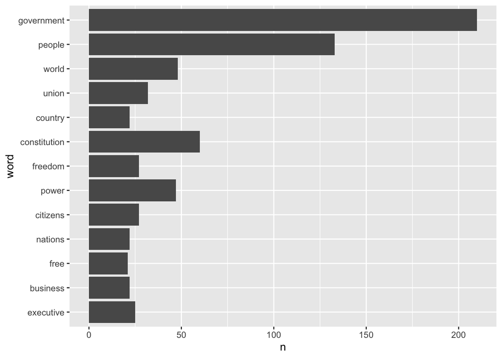

```r
text_dat_freq %>%
  mutate(word = reorder(word,n)) %>%
  slice(1:25) %>%
  ggplot(aes(word,n)) +
  geom_col() +
  coord_flip()
```

Let’s look at the top ten words by president.

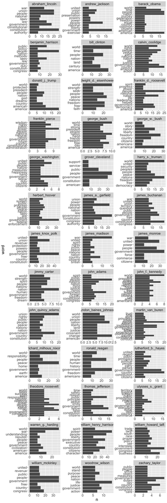

```r
text_dat_freq %>%
  group_by(president) %>%
  top_n(10,n) %>%
  ggplot(aes(word,n)) +
  geom_col() +
  coord_flip() +
  facet_wrap(~president,scales = "free",ncol=3) +
  theme(text = element_text(size=18))
```

## Sentiment

Let’s examine the sentiment of the speeches.

```r
text_dat_sent <-
  text_dat %>%
  inner_join(get_sentiments("afinn"),by='word')

text_dat_sent
```

```
## # A tibble: 8,469 x 7
##    president         address date        year length word        value
##    <chr>             <chr>   <date>     <dbl>  <int> <chr>       <dbl>
##  1 george_washington first   1789-04-30  1789   8641 love            3
##  2 george_washington first   1789-04-30  1789   8641 retreat        -1
##  3 george_washington first   1789-04-30  1789   8641 hopes           2
##  4 george_washington first   1789-04-30  1789   8641 retreat        -1
##  5 george_washington first   1789-04-30  1789   8641 dear            2
##  6 george_washington first   1789-04-30  1789   8641 waste          -1
##  7 george_washington first   1789-04-30  1789   8641 committed       1
##  8 george_washington first   1789-04-30  1789   8641 trust           1
##  9 george_washington first   1789-04-30  1789   8641 distrustful    -3
## 10 george_washington first   1789-04-30  1789   8641 inferior       -2
## # … with 8,459 more rows
```

On Average, which president was “most postive”?

```r
text_dat_sent %>%
  group_by(president,year,address) %>%
  summarize(ave_score = mean(value)) %>%
  ungroup %>%
  filter(ave_score == max(ave_score))
```

```
## # A tibble: 1 x 4
##   president    year address ave_score
##   <chr>       <dbl> <chr>       <dbl>
## 1 george_bush  1989 second       1.20
```

The most negative?

```r
text_dat_sent %>%
  group_by(president,year,address) %>%
  summarize(ave_score = mean(value)) %>%
  ungroup %>%
  filter(ave_score == min(ave_score))
```

```
## # A tibble: 1 x 4
##   president        year address ave_score
##   <chr>           <dbl> <chr>       <dbl>
## 1 abraham_lincoln  1861 first      -0.152
```

Let’s examine the sentiment of the most recent Republican presidents.

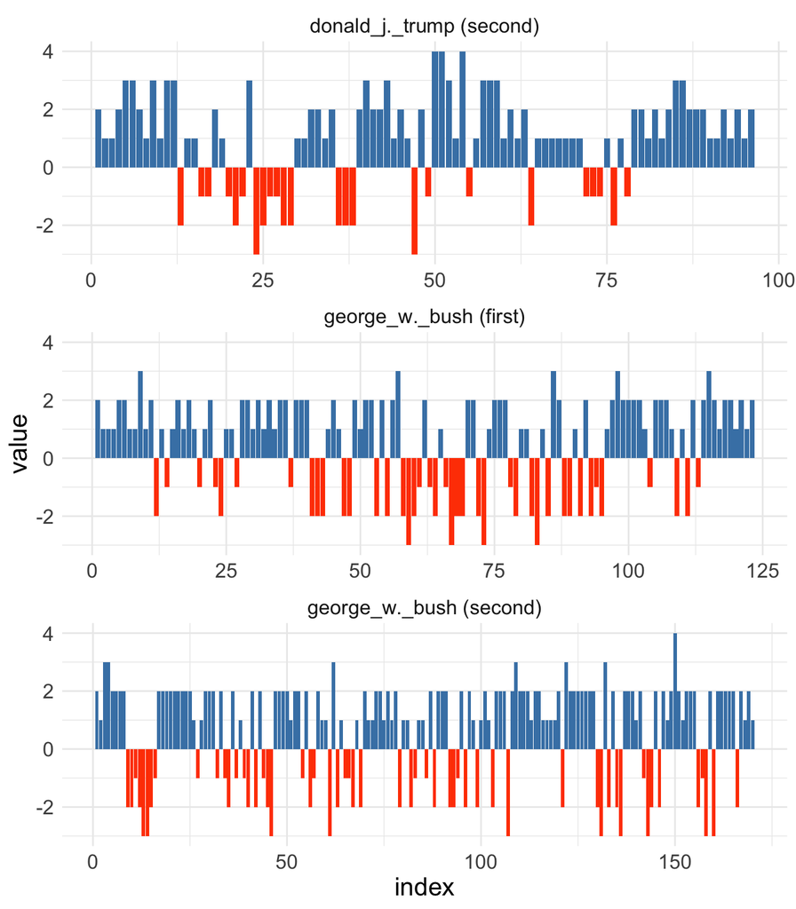

```r
text_dat_sent %>%
  filter(president %in% c("george_w._bush","donald_j._trump")) %>%
  group_by(president,address) %>%
  mutate(index = row_number()) %>%
  ungroup %>%
  mutate(id = str_glue("{president} ({address})"),
         classify = ifelse(value>0,"steelblue","orangered")) %>%

  # Now plot
  ggplot(aes(index,value,fill=classify)) +
  geom_col(show.legend = F) +
  facet_wrap(~id,scales = "free_x",ncol=1) +
  scale_fill_identity() +
  theme_minimal() +
  theme(text = element_text(size=16))
```

Let’s explore a different sentiment classifier and see if we get a similar story. Note that we’ll do *everything* all in one seamless pipeline. Recall that the `bing` sentiment classifier is binary (“positive”/“negative”)

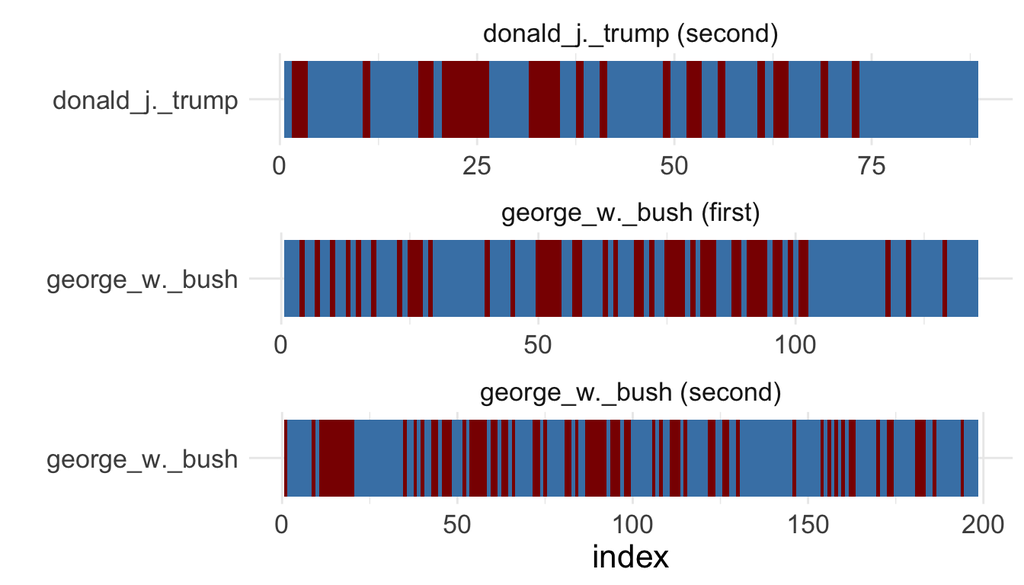

```r
# First Classify
text_dat %>%
  inner_join(get_sentiments("bing"),by='word') %>%


  # Next subset out the relevant presidents
  filter(president %in% c("george_w._bush","donald_j._trump")) %>%
  group_by(president,address) %>%
  mutate(index = row_number()) %>%
  ungroup %>%
  mutate(id = str_glue("{president} ({address})"),
         classify = ifelse(sentiment=="positive","steelblue","darkred")) %>%

  # Now plot
  ggplot(aes(index,president,fill=classify)) +
  geom_tile(show.legend = F) +
  facet_wrap(~id,scales = "free",ncol=1) +
  scale_fill_identity() +
  labs(y="") +
  theme_minimal() +
  theme(text = element_text(size=16))
```

Looks largely the same…

## Topic Models

Let’s subset the text and convert to a document term matrix.

```r
dtm <-
  text_dat %>%
  # filter(year >= 1989) %>%
  mutate(id = str_glue("{president} ({address})")) %>%
  group_by(id) %>%
  count(word) %>%
  ungroup %>%
  cast_dtm(document = id,term = word,value = n)

dtm
```

```
## <<DocumentTermMatrix (documents: 56, terms: 8611)>>
## Non-/sparse entries: 32955/449261
## Sparsity           : 93%
## Maximal term length: 17
## Weighting          : term frequency (tf)
```

```r
inaug_lda <- LDA(dtm,k=2,control = list(seed = 1234))
```

Let’s explore the topic output.

What are the top ten words most associated with each topic?

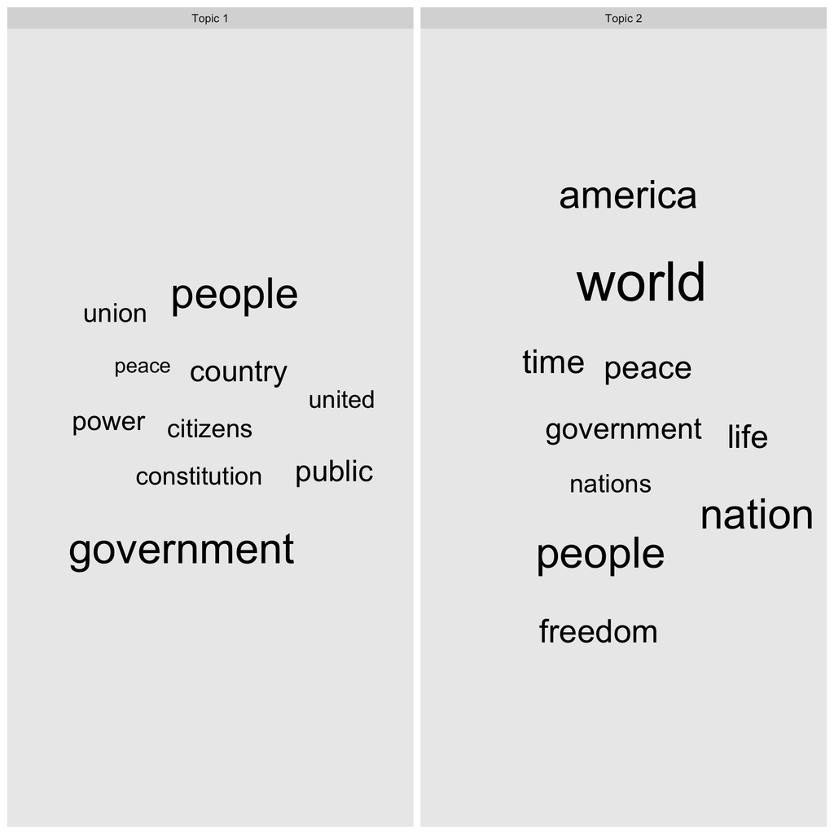

```r
# Extract the term to topic associations
inaug_lda %>%
  tidy(metric="beta") %>%

  # Convert topics metrics to proportions
  group_by(topic) %>%
  mutate(prop = beta/sum(beta)) %>%

  # Grab the top 10
  top_n(10,prop) %>%
  ungroup %>%

  # Rename topic label
  mutate(topic_label = str_glue("Topic {topic}")) %>%

  # Plot as word cloud
  ggplot(aes(label=term,size=prop)) +
  ggwordcloud::geom_text_wordcloud_area() +
  scale_size_area(max_size = 15) +
  facet_wrap(~topic_label,scales="free",ncol=2)
```

Can we associate meaning to these topics?

Let’s associate presidents speeches to specific topic entries. We can easily re-associate our topic allocations with the words used to find which presidents were most associated with the two topics.

```r
pres_topic_member <- tidy(inaug_lda,"gamma") %>%
  mutate(gamma = round(gamma,3))
pres_topic_member
```

```
## # A tibble: 112 x 3
##    document                   topic gamma
##    <chr>                      <int> <dbl>
##  1 abraham_lincoln (first)        1 0.77
##  2 abraham_lincoln (second)       1 0.805
##  3 andrew_jackson (first)         1 1
##  4 andrew_jackson (second)        1 0.983
##  5 barack_obama (first)           1 0
##  6 barack_obama (second)          1 0
##  7 benjamin_harrison (second)     1 1
##  8 bill_clinton (first)           1 0
##  9 bill_clinton (second)          1 0
## 10 calvin_coolidge (second)       1 0.471
## # … with 102 more rows
```

Let’s now re-assign the years.

```r
year_key <-
  text_dat %>%
  mutate(document = str_glue("{president} ({address})") %>% as.character) %>%
  select(document,year) %>%
  unique()

year_key
```

```
## # A tibble: 58 x 2
##    document                    year
##    <chr>                      <dbl>
##  1 george_washington (first)   1789
##  2 george_washington (second)  1793
##  3 john_adams (second)         1797
##  4 thomas_jefferson (first)    1801
##  5 thomas_jefferson (second)   1805
##  6 james_madison (first)       1809
##  7 james_madison (second)      1813
##  8 james_monroe (first)        1817
##  9 james_monroe (second)       1821
## 10 john_quincy_adams (second)  1825
## # … with 48 more rows
```

Merge the two data sources and examine the change in topic membership over time…

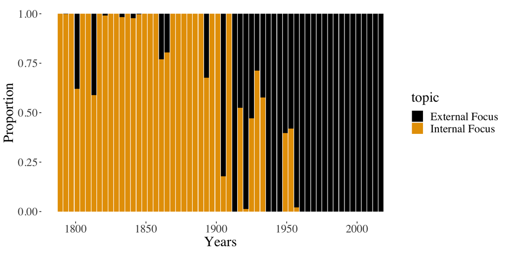

```r
full_join(pres_topic_member,year_key,by = "document") %>%
  mutate(topic = ifelse(topic==1,"Internal Focus","External Focus")) %>%
  ggplot(aes(year,gamma,fill=topic)) +
  geom_col(position="stack") +
  ggthemes::scale_fill_colorblind() +
  ggthemes::theme_tufte() +
  labs(y="Proportion",x="Years") +
  theme(text=element_text(size=20))
```